# 01_Muestreo_Sistematico

LMT

noviembre de 2021

## Muestreo Sistemático

Recordar que la ventaja principal de una muestra probabilística es que nos permite usar teoría estadística para hacer inferencia sobre la población y con ello se tiene la capacidad de producir medidas de error y precisión.

Consiste en elegir una muestra en la cual solamente el primer elemento se toma al azar y el resto se selecciona sistemáticamente.

Pude ser combinado con otros procedimientos de muestreo, y puede ser utilizado en la practica por su relativa facilidad de administración en el trabajo de campo.

Pasos para elegir una muestra sistemática:

1. definir la longitud del intervalo de muestreo

$q = \frac{N}{n}$

Si N no es divisible por n, se toma $q$ como el entero inmediato anterior y habrá muestras que sean de tamaño n y otras de tamaño n+1.

2. Seleccionar $q_0$ que sea un número entero aleatorio entre 1 y $q$.
3. Seleccionar los siguientes elementos para que compongan la muestra

$\{q, q_0 + q, q_0 + 2q, q_0 + 3q, \dots , q_0 + (n-1)q \}$

**ejemplo**

```r
# Limpiar área de trabajo
rm(list = ls())
```

```r
# Cargar librerías
suppressMessages(library(tidyverse))
library(ggplot2)
library(readr)
library(stringr)
```

```r
suppressMessages(precios <- read_csv("/home/leonardo/Documentos/Acatlan/datos/HousePrices/HousePrices.csv") %>% select(Id,SalePrice))
glimpse(precios)
```

```
## Rows: 1,460
## Columns: 2
## $ Id        <dbl> 1, 2, 3, 4, 5, 6, 7, 8, 9, 10, 11, 12, 13, 14, 15, 16,…
## $ SalePrice <dbl> 208500, 181500, 223500, 140000, 250000, 143000, 307000…
```

```r
head(precios, n = 20)
```

```
## # A tibble: 20 x 2
##       Id SalePrice
##    <dbl>     <dbl>
##  1     1    208500
##  2     2    181500
##  3     3    223500
##  4     4    140000
##  5     5    250000
##  6     6    143000
##  7     7    307000
##  8     8    200000
##  9     9    129900
## 10    10    118000
## 11    11    129500
## 12    12    345000
## 13    13    144000
## 14    14    279500
## 15    15    157000
## 16    16    132000
## 17    17    149000
## 18    18     90000
## 19    19    159000
## 20    20    139000
```

Definimos N y n

```r
N <- dim(precios)[1]
n <- 100
```

definimos el intervalo

```r
q <- floor(N/n)
q
```

```
## [1] 14
```

definimos $q_0$. Recordar que si $u$ ~ $unif(0,1)$ entonces $(b-a) \cdot u + a$ ~ $unif(a,b)$

```r
set.seed(12345)
u <- runif(1)
q0 <- round((q-0)*u + 0)
q0
```

```
## [1] 10
```

La muestra está compuesta por los elementos:

primero obtenemos el corte de los intervalos

```r
vector_multiplos_q <- q*0:(n-1)
length(vector_multiplos_q)
```

```
## [1] 100
```

```r
vector_multiplos_q
```

```
##   [1]    0   14   28   42   56   70   84   98  112  126  140  154  168  182
##  [15]  196  210  224  238  252  266  280  294  308  322  336  350  364  378
##  [29]  392  406  420  434  448  462  476  490  504  518  532  546  560  574
##  [43]  588  602  616  630  644  658  672  686  700  714  728  742  756  770
##  [57]  784  798  812  826  840  854  868  882  896  910  924  938  952  966
##  [71]  980  994 1008 1022 1036 1050 1064 1078 1092 1106 1120 1134 1148 1162
##  [85] 1176 1190 1204 1218 1232 1246 1260 1274 1288 1302 1316 1330 1344 1358
##  [99] 1372 1386
```

obtenemos el índice de los elementos

```r
indice_elementos <- round(q0 + vector_multiplos_q)
indice_elementos
```

```
##   [1]   10   24   38   52   66   80   94  108  122  136  150  164  178  192
##  [15]  206  220  234  248  262  276  290  304  318  332  346  360  374  388
##  [29]  402  416  430  444  458  472  486  500  514  528  542  556  570  584
##  [43]  598  612  626  640  654  668  682  696  710  724  738  752  766  780
##  [57]  794  808  822  836  850  864  878  892  906  920  934  948  962  976
##  [71]  990 1004 1018 1032 1046 1060 1074 1088 1102 1116 1130 1144 1158 1172
##  [85] 1186 1200 1214 1228 1242 1256 1270 1284 1298 1312 1326 1340 1354 1368
##  [99] 1382 1396
```

```r
muestra_sistematica <- precios %>%
                        slice(indice_elementos)

glimpse(muestra_sistematica)
```

```
## Rows: 100
## Columns: 2
## $ Id        <dbl> 10, 24, 38, 52, 66, 80, 94, 108, 122, 136, 150, 164, 1…
## $ SalePrice <dbl> 118000, 129900, 153000, 114500, 317000, 110000, 133900…
```

**pregunta**. En muestreo sistemático, ¿cuántas muestras puede haber?. Las posibles muestras son $q$ (14)

**pregunta**. En muestreo aleatorio simple, ¿cuántas muestras puede haber?. Las posibles muestras son combinaciones de 100 en 1,460.

Para fines de estimación, se tiene que la probabilidad de seleccionar en la muestra cualquier elemento es $\frac{n}{N}$

```r
muestra_sistematica %>% summarise(precio_promedio = mean(SalePrice)/1000)
```

```
## # A tibble: 1 x 1
##   precio_promedio
##             <dbl>
## 1            178.
```

```r
precios %>% summarise(precio_promedio = mean(SalePrice)/1000)
```

```
## # A tibble: 1 x 1
##   precio_promedio
##             <dbl>
## 1            181.
```

Se puede ver al muestreo sistemático como un caso particular del muestreo por conglomerados en 1 etapa, no obstante no es posible utilizar el estimador de la varianza. en términos de muestreo por conglomerados, tendríamos n = 1 y mi = Mi

En el caso de que ordenemos de manera aleatoria los elementos de la población, equivaldría a muestreo aleatorio simple.

### Orden de los elementos de la población respecto a la variable de interés

1. Los elementos de la población aparecen en orden aleatorio.

En este caso, es altamente problable que el muestreo sistemático produzca una muestra que se comporte como una muestra aleatoria.

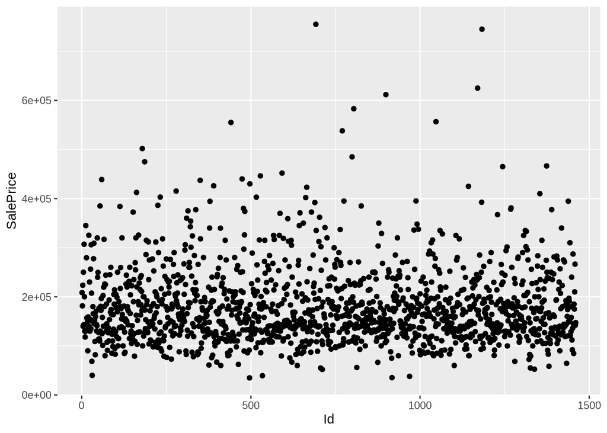

```r
ggplot(data = precios) +
  geom_point(mapping = aes(x = Id, y = SalePrice))
```

2. Los elementos de la población aparecen en orden creciente o decreciente.

En este caso es más probable que el muestreo sistemático sea más preciso que el muestreo aleatorio. Esto se debe a que la muestra queda más dispersa en la población. Intuitivamente, en este caso el muestreo sistemático contendrá elementos en todos los rangos de la población.

```r
precios_ordenados <- precios %>%
                    arrange(SalePrice) %>%
                    mutate(id_ordenada = row_number())

head(precios_ordenados)
```

```
## # A tibble: 6 x 3
##      Id SalePrice id_ordenada
##   <dbl>     <dbl>       <int>
## 1   496     34900           1
## 2   917     35311           2
## 3   969     37900           3
## 4   534     39300           4
## 5    31     40000           5
## 6   711     52000           6
```

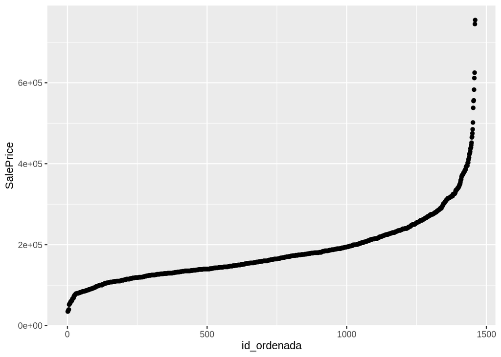

```r
ggplot(data = precios_ordenados) +
  geom_point(mapping = aes(x = id_ordenada, y = SalePrice))
```

3. Los elementos aparecen en un orden periódico.

En este caso el muestreo sistématico será menos preciso que muestreo aleatorio ya que podría pasar que la muestra sistemática contenga elementos cuyos valores sean muy similares.

```r
precios_periodicos <- precios_ordenados %>%
                      mutate(periodo = id_ordenada %% q,
                             periodo = ifelse(periodo == 0, q, periodo)) %>%
                      arrange(periodo) %>%
                      mutate(id_periodico = row_number())


head(precios_periodicos, n = 25)
```

```
## # A tibble: 25 x 5
##       Id SalePrice id_ordenada periodo id_periodico
##    <dbl>     <dbl>       <int>   <dbl>        <int>
##  1   496     34900           1       1            1
##  2   376     61000          15       1            2
##  3   330     78000          29       1            3
##  4  1062     81000          43       1            4
##  5  1050     84900          57       1            5
##  6   343     87500          71       1            6
##  7   999     91000          85       1            7
##  8    98     94750          99       1            8
##  9   973     99500         113       1            9
## 10  1010    102000         127       1           10
## # … with 15 more rows
```

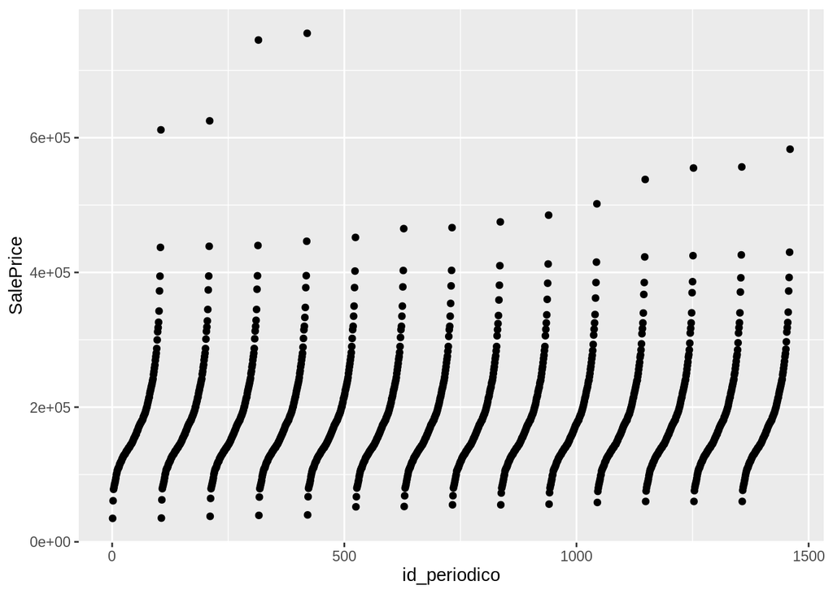

```r
ggplot(data = precios_periodicos) +
  geom_point(mapping = aes(x = id_periodico, y = SalePrice))
```

```r
precios_periodicos %>%  filter(SalePrice > 400000)
```

```
## # A tibble: 28 x 5
##       Id SalePrice id_ordenada periodo id_periodico
##    <dbl>     <dbl>       <int>   <dbl>        <int>
##  1   350    437154        1443       1          104
##  2   899    611657        1457       1          105
##  3    59    438780        1444       2          209
##  4  1170    625000        1458       2          210
##  5   474    440000        1445       3          314
##  6  1183    745000        1459       3          315
##  7   528    446261        1446       4          419
##  8   692    755000        1460       4          420
##  9   662    402000        1433       5          523
## 10   592    451950        1447       5          524
## # … with 18 more rows
```

**Muestras**

1. Elemento ordenados al azar

```r
indice_elementos1 <- indice_elementos
muestra_sistematica1 <- precios %>%
                        slice(indice_elementos1)

glimpse(muestra_sistematica1)
```

```
## Rows: 100
## Columns: 2
## $ Id        <dbl> 10, 24, 38, 52, 66, 80, 94, 108, 122, 136, 150, 164, 1…
## $ SalePrice <dbl> 118000, 129900, 153000, 114500, 317000, 110000, 133900…
```

```r
muestra_sistematica1 %>% summarise(precio_promedio = mean(SalePrice)/1000)
```

```
## # A tibble: 1 x 1
##   precio_promedio
##             <dbl>
## 1            178.
```

2. Elemento ordenados de forma ascendente

```r
indice_elementos2 <- indice_elementos + 50
muestra_sistematica2 <- precios_ordenados %>%
                        slice(indice_elementos2)

glimpse(muestra_sistematica2)
```

```
## Rows: 100
## Columns: 3
## $ Id          <dbl> 639, 913, 1073, 515, 122, 730, 810, 554, 871, 901, 5…
## $ SalePrice   <dbl> 85000, 88000, 91500, 96500, 100000, 103000, 106000, …
## $ id_ordenada <int> 60, 74, 88, 102, 116, 130, 144, 158, 172, 186, 200, …
```

```r
muestra_sistematica2 %>% summarise(precio_promedio = mean(SalePrice)/1000)
```

```
## # A tibble: 1 x 1
##   precio_promedio
##             <dbl>
## 1            183.
```

3. Elemento que muestran una periodicidad

```r
indice_elementos3 <- indice_elementos  + 98
muestra_sistematica3 <- precios_periodicos %>%
                        slice(indice_elementos3)

glimpse(muestra_sistematica3)
```

```
## Rows: 97
## Columns: 5
## $ Id           <dbl> 156, 1201, 426, 522, 1042, 1139, 1134, 12, 712, 381…
## $ SalePrice    <dbl> 79000, 116050, 135000, 150000, 173000, 196000, 2395…
## $ id_ordenada  <int> 30, 226, 422, 618, 814, 1010, 1206, 1402, 129, 325,…
## $ periodo      <dbl> 2, 2, 2, 2, 2, 2, 2, 2, 3, 3, 3, 3, 3, 3, 3, 4, 4, …
## $ id_periodico <int> 108, 122, 136, 150, 164, 178, 192, 206, 220, 234, 2…
```

```r
muestra_sistematica3 %>% summarise(precio_promedio = mean(SalePrice)/1000)
```

```
## # A tibble: 1 x 1
##   precio_promedio
##             <dbl>
## 1            181.
```

**ventajas**

- Es más fácil seleccionar una muestra que en muestreo aleatorio.
- Es factible producir una muestra representativa.

**desventajas**

- Un mal arreglo en el marco puede producir muestras ineficientes.
- No se pueden calcular estimadores de varianza con 1 sola muestra sistemática.

El muestreo sistemático puede llegar a ser utilizado para seleccionar unidades secundarias (USM).

Nota. En el pasado no se tenía la facilidad computacional que se tiene ahora y se llegaba a trabajar tanto con tablas de probabilidad como con tablas de números aleatorios. Es por ello que el uso de muestreo sistemático podía ser una de las razones por las cuales era sencillo seleccionar una muestra de esa manera.

Nota. No hay expresiones válidas para estimadores de varianza cuando se usa muestreo sistemático, pero si los elementos están ordenados, se pueden utilizar expresiones de muestreo aleatorio como una aproximación y resulta un método conservador ya que las varianzas suelen ser menores.